# Beta Prior for Bernoulli

Tom Fletcher

January 18, 2018

In this note we will look at the conjugate prior of the Bernoulli distribution, which is a Beta distribution. Recall that Bernoulli is the distribution for a binary random variable. The notation $X \sim \mathrm{Ber}(\theta)$ means $P(X = 1) = \theta$ and $P(X = 0) = 1 - \theta$. Now, if we are given $n$ realizations of this Bernoulli variable, the likelihood function for $\theta$ is

$$\mathcal{L}(\theta) = \prod_{i=1}^n P(X = x_i | \theta) = \prod_{i=1}^n \theta^{x_i} (1-\theta)^{1-x_i}.$$

If we let $k$ be the number of $x_i$ with value $1$, i.e., $k = \sum_i x_i$, the likelihood function is written in more simple form as

$$\mathcal{L}(\theta) = \theta^k (1-\theta)^{n-k}.$$

Now let’s look at putting a Beta distribution on the parameter $\theta$ of the Bernoulli likelihood. The notation for the Beta distribution is $\theta \sim \mathrm{Beta}(\alpha, \beta)$, and its pdf is given by

$$p(\theta) = \frac{1}{\mathrm{B}(\alpha, \beta)} \theta^{\alpha - 1} (1 - \theta)^{\beta - 1}, \quad\quad \text{for $\theta \in [0,1]$},$$

where $\mathrm{B}(\alpha, \beta)$ is the Beta function.

**Note:** $\mathrm{Beta}(1, 1)$ is the same as the uniform distribution, $U(0, 1)$.

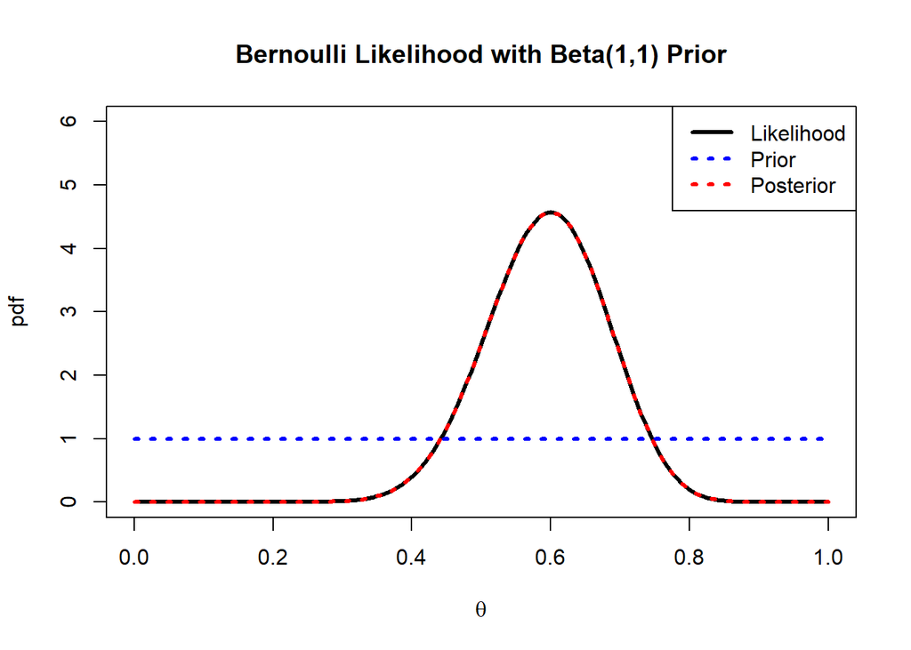

```r
## x-axis for plotting
numSteps = 200
x = seq(0, 1, 1 / numSteps)

## Say we observe 30 coin flips, 18 heads, 12 tails
## Likelihood function:
k = 18
n = 30
L = x^k * (1 - x)^(n - k)

## Just normalize likelihood to integrate to one (for purposes of plotting)
L = L / sum(L) * numSteps


### Uniform Prior
## Plot likelihood

plot(x, L, type = 'l', lwd = 3, ylim = c(0,6),
     main = "Bernoulli Likelihood with Beta(1,1) Prior",
     xlab = expression(theta), ylab = "pdf")

## Plot Beta(1,1) prior
lines(x, dbeta(x, 1, 1), lty = 3, lwd = 3, col = "blue")

## Plot posterior
lines(x, dbeta(x, k + 1, n - k + 1), lty = 3, lwd = 3, col = "red")

legend("topright", c("Likelihood", "Prior", "Posterior"),
       lty = c(1, 3, 3), lwd = 3, col = c("black", "blue", "red"))
```

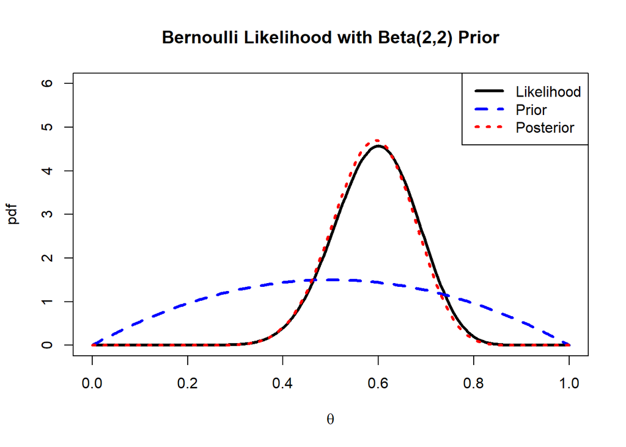

```r
### Beta(2, 2) Prior
plot(x, L, type = 'l', lwd = 3, ylim = c(0,6),
     main = "Bernoulli Likelihood with Beta(2,2) Prior",
     xlab = expression(theta), ylab = "pdf")

## Plot Beta(2,2) prior
lines(x, dbeta(x, 2, 2), lty = 2, lwd = 3, col = "blue")

## Plot posterior
lines(x, dbeta(x, k + 2, n - k + 2), lty = 3, lwd = 3, col = "red")

legend("topright", c("Likelihood", "Prior", "Posterior"),
       lty = c(1, 2, 3), lwd = 3, col = c("black", "blue", "red"))
```

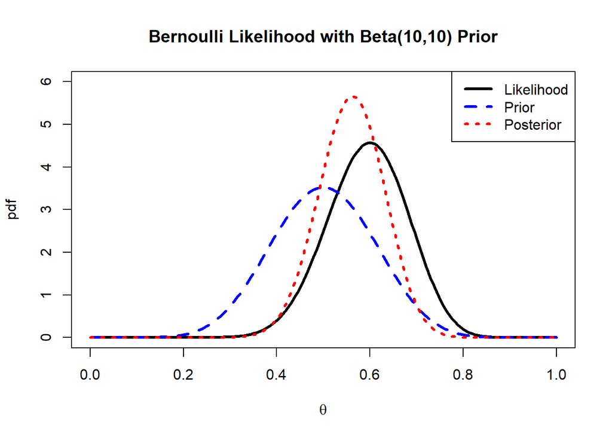

```r
### Beta(10, 10) Prior
plot(x, L, type = 'l', lwd = 3, ylim = c(0,6),
     main = "Bernoulli Likelihood with Beta(10,10) Prior",
     xlab = expression(theta), ylab = "pdf")

## Plot Beta(1,1) prior
lines(x, dbeta(x, 10, 10), lty = 2, lwd = 3, col = "blue")

## Plot posterior
lines(x, dbeta(x, k + 10, n - k + 10), lty = 3, lwd = 3, col = "red")

legend("topright", c("Likelihood", "Prior", "Posterior"),
       lty = c(1, 2, 3), lwd = 3, col = c("black", "blue", "red"))
```

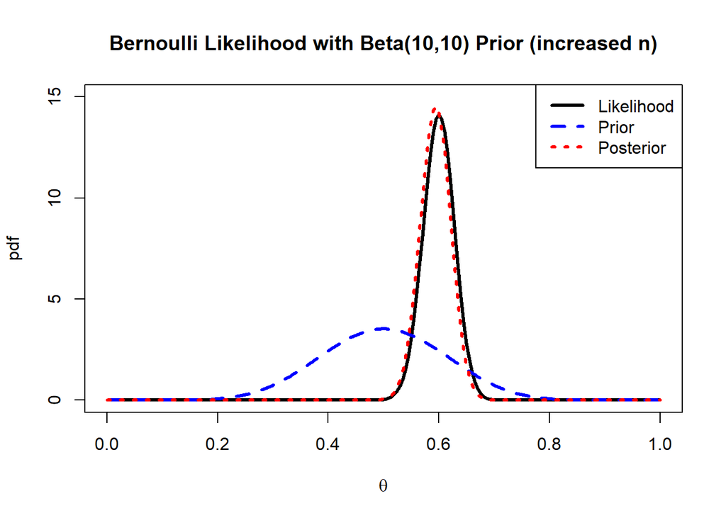

```r
### Beta(10, 10) Prior, but increase n by 10
n = 300
k = 180

L = x^k * (1 - x)^(n - k)
L = L / sum(L) * numSteps

plot(x, L, type = 'l', lwd = 3, ylim = c(0,15),
     main = "Bernoulli Likelihood with Beta(10,10) Prior (increased n)",
     xlab = expression(theta), ylab = "pdf")

## Plot Beta(10,10) prior
lines(x, dbeta(x, 10, 10), lty = 2, lwd = 3, col = "blue")

## Plot posterior
lines(x, dbeta(x, k + 10, n - k + 10), lty = 3, lwd = 3, col = "red")

legend("topright", c("Likelihood", "Prior", "Posterior"),
       lty = c(1, 2, 3), lwd = 3, col = c("black", "blue", "red"))
```

## Laplace’s Analysis of Sex Ratio at Birth

Here y is the number of female births, n is total number of births in Paris from 1745 to 1770

```r
y = 241945
n = y + 251527
```

### Frequentist Analysis

First, let’s look at the frequentist analysis. MLE for the proportion of female births

```r
(theta.hat = y / n)
```

```
[1] 0.4902912
```

Here is the 95% confidence interval (using a normal approximation):

```r
se = sqrt(theta.hat * (1 - theta.hat) / n)
theta.hat + c(-se, se) * qnorm(0.975)
```

```
[1] 0.4888965 0.4916860
```

Here is the frequentist hypothesis test, again using a normal approximation.

- Null hypothesis: $\theta = 0.5$
- Alt hypothesis: $\theta < 0.5$

Test statistic:

```r
alpha = 0.05
(z = (theta.hat - 0.5) / (0.5 / sqrt(n)))
```

```
[1] -13.64033
```

$p$-value:

```r
pnorm(z)
```

```
[1] 1.15256e-42
```

### Bayesian Analysis

Now, let’s look at Laplace’s analysis (the Bayesian analysis). Assuming a uniform prior for $p(\theta)$.

Posterior is given by $\mathrm{Beta}(y + 1, n - y + 1).$ Posterior probability that more girls are born than boys is: $P(\theta >= 0.5 \mid y)$

```r
1 - pbeta(0.5, y + 1, n - y + 1)
```

```
[1] 0
```

Note this is zero up to numerical calculation of the beta integral We can compute the log probability, and use the fact that: $\log(1 - x)$ is approximately $-x$ for small $x$:

```r
-pbeta(0.5, y + 1, n - y + 1, log.p = TRUE)
```

```
[1] 1.146058e-42
```

Notice that the p-value and the posterior probability are actually quite similar. Go back and try some other values for y and n and re-run (particularly smaller sample sizes). How do the p-value and posterior probability compare?